# STAT 486/586

Jarad Niemi

2023-02-07

R code

We will start with loading up the necessary packages using the `library()` command.

```r
library("tidyverse")
```

# Data transformation

The dplyr package provides a number of convenience functions for dealing with `data.frame` objects in R. As a reminder, a `data.frame` is a special matrix that allows different columns to have different data types.

Although, we will focus on the [dplyr package](https://dplyr.tidyverse.org/), you may want to look up the [data.table package](https://cran.r-project.org/web/packages/data.table/index.html). Generally, dplyr tries to make the code readable while data.table tries to make the most efficient code.

Technically, the output of a dplyr function is a `tibble` which is a specialized `data.frame`.

## tibble

```r
?tibble
```

```r
ToothGrowth
```

```
##     len supp dose
## 1   4.2   VC  0.5
## 2  11.5   VC  0.5
## 3   7.3   VC  0.5
## 4   5.8   VC  0.5
## 5   6.4   VC  0.5
## 6  10.0   VC  0.5
## 7  11.2   VC  0.5
## 8  11.2   VC  0.5
## 9   5.2   VC  0.5
## 10  7.0   VC  0.5
## 11 16.5   VC  1.0
## 12 16.5   VC  1.0
## 13 15.2   VC  1.0
## 14 17.3   VC  1.0
```

[output cut: 46 more lines]

vs

```r
as_tibble(ToothGrowth)
```

```
## # A tibble: 60 × 3
##      len supp   dose
##    <dbl> <fct> <dbl>
##  1   4.2 VC      0.5
##  2  11.5 VC      0.5
##  3   7.3 VC      0.5
##  4   5.8 VC      0.5
##  5   6.4 VC      0.5
##  6  10   VC      0.5
##  7  11.2 VC      0.5
##  8  11.2 VC      0.5
##  9   5.2 VC      0.5
## 10   7   VC      0.5
## # … with 50 more rows
```

## Filtering observations

Filter means to remove a set of observations according to some criterion.

### base R

```r
ToothGrowth[ToothGrowth$supp == "VC", ]
```

```
##     len supp dose
## 1   4.2   VC  0.5
## 2  11.5   VC  0.5
## 3   7.3   VC  0.5
## 4   5.8   VC  0.5
## 5   6.4   VC  0.5
## 6  10.0   VC  0.5
## 7  11.2   VC  0.5
## 8  11.2   VC  0.5
## 9   5.2   VC  0.5
## 10  7.0   VC  0.5
## 11 16.5   VC  1.0
## 12 16.5   VC  1.0
## 13 15.2   VC  1.0
## 14 17.3   VC  1.0
```

[output cut: 16 more lines]

```r
subset(ToothGrowth, supp == "VC")
```

```
##     len supp dose
## 1   4.2   VC  0.5
## 2  11.5   VC  0.5
## 3   7.3   VC  0.5
## 4   5.8   VC  0.5
## 5   6.4   VC  0.5
## 6  10.0   VC  0.5
## 7  11.2   VC  0.5
## 8  11.2   VC  0.5
## 9   5.2   VC  0.5
## 10  7.0   VC  0.5
## 11 16.5   VC  1.0
## 12 16.5   VC  1.0
## 13 15.2   VC  1.0
## 14 17.3   VC  1.0
```

[output cut: 16 more lines]

or

```r
ToothGrowth[ToothGrowth$len < 10, ]
```

```
##    len supp dose
## 1  4.2   VC  0.5
## 3  7.3   VC  0.5
## 4  5.8   VC  0.5
## 5  6.4   VC  0.5
## 9  5.2   VC  0.5
## 10 7.0   VC  0.5
## 34 9.7   OJ  0.5
## 37 8.2   OJ  0.5
## 38 9.4   OJ  0.5
## 40 9.7   OJ  0.5
```

```r
subset(ToothGrowth, len < 10)
```

```
##    len supp dose
## 1  4.2   VC  0.5
## 3  7.3   VC  0.5
## 4  5.8   VC  0.5
## 5  6.4   VC  0.5
## 9  5.2   VC  0.5
## 10 7.0   VC  0.5
## 34 9.7   OJ  0.5
## 37 8.2   OJ  0.5
## 38 9.4   OJ  0.5
## 40 9.7   OJ  0.5
```

```r
subset(ToothGrowth, len < 10 & supp == "VC") # using the AND operator &
```

```
##    len supp dose
## 1  4.2   VC  0.5
## 3  7.3   VC  0.5
## 4  5.8   VC  0.5
## 5  6.4   VC  0.5
## 9  5.2   VC  0.5
## 10 7.0   VC  0.5
```

### dplyr::filter

Note that `dplyr::filter` masks `stats::filter()`. We will be explicit here and call the `filter` function from the `dplyr` package using the double colon operator.

```r
?`::`
```

```r
dplyr::filter(ToothGrowth, supp == "VC")
```

```
##     len supp dose
## 1   4.2   VC  0.5
## 2  11.5   VC  0.5
## 3   7.3   VC  0.5
## 4   5.8   VC  0.5
## 5   6.4   VC  0.5
## 6  10.0   VC  0.5
## 7  11.2   VC  0.5
## 8  11.2   VC  0.5
## 9   5.2   VC  0.5
## 10  7.0   VC  0.5
## 11 16.5   VC  1.0
## 12 16.5   VC  1.0
## 13 15.2   VC  1.0
## 14 17.3   VC  1.0
```

[output cut: 16 more lines]

```r
dplyr::filter(ToothGrowth, len < 10)
```

```
##    len supp dose
## 1  4.2   VC  0.5
## 2  7.3   VC  0.5
## 3  5.8   VC  0.5
## 4  6.4   VC  0.5
## 5  5.2   VC  0.5
## 6  7.0   VC  0.5
## 7  9.7   OJ  0.5
## 8  8.2   OJ  0.5
## 9  9.4   OJ  0.5
## 10 9.7   OJ  0.5
```

```r
dplyr::filter(ToothGrowth, len < 10, supp == "VC")
```

```
##   len supp dose
## 1 4.2   VC  0.5
## 2 7.3   VC  0.5
## 3 5.8   VC  0.5
## 4 6.4   VC  0.5
## 5 5.2   VC  0.5
## 6 7.0   VC  0.5
```

## arrange

Arrange arranges the `data.frame` according to a variable.

### base R

```r
ToothGrowth[order(ToothGrowth$len), ]
```

```
##     len supp dose
## 1   4.2   VC  0.5
## 9   5.2   VC  0.5
## 4   5.8   VC  0.5
## 5   6.4   VC  0.5
## 10  7.0   VC  0.5
## 3   7.3   VC  0.5
## 37  8.2   OJ  0.5
## 38  9.4   OJ  0.5
## 34  9.7   OJ  0.5
## 40  9.7   OJ  0.5
## 6  10.0   VC  0.5
## 36 10.0   OJ  0.5
## 7  11.2   VC  0.5
## 8  11.2   VC  0.5
```

[output cut: 46 more lines]

What happens if we want to arrange by supp and then by dose? I don’t know.

### dplyr::arrange

```r
arrange(ToothGrowth, len)
```

```
##     len supp dose
## 1   4.2   VC  0.5
## 2   5.2   VC  0.5
## 3   5.8   VC  0.5
## 4   6.4   VC  0.5
## 5   7.0   VC  0.5
## 6   7.3   VC  0.5
## 7   8.2   OJ  0.5
## 8   9.4   OJ  0.5
## 9   9.7   OJ  0.5
## 10  9.7   OJ  0.5
## 11 10.0   VC  0.5
## 12 10.0   OJ  0.5
## 13 11.2   VC  0.5
## 14 11.2   VC  0.5
```

[output cut: 46 more lines]

```r
arrange(ToothGrowth, supp, dose)
```

```
##     len supp dose
## 1  15.2   OJ  0.5
## 2  21.5   OJ  0.5
## 3  17.6   OJ  0.5
## 4   9.7   OJ  0.5
## 5  14.5   OJ  0.5
## 6  10.0   OJ  0.5
## 7   8.2   OJ  0.5
## 8   9.4   OJ  0.5
## 9  16.5   OJ  0.5
## 10  9.7   OJ  0.5
## 11 19.7   OJ  1.0
## 12 23.3   OJ  1.0
## 13 23.6   OJ  1.0
## 14 26.4   OJ  1.0
```

[output cut: 46 more lines]

## Selecting variables

Here we will select which columns to keep.

### base::subset

```r
ToothGrowth[, c("len","dose")]
```

```
##     len dose
## 1   4.2  0.5
## 2  11.5  0.5
## 3   7.3  0.5
## 4   5.8  0.5
## 5   6.4  0.5
## 6  10.0  0.5
## 7  11.2  0.5
## 8  11.2  0.5
## 9   5.2  0.5
## 10  7.0  0.5
## 11 16.5  1.0
## 12 16.5  1.0
## 13 15.2  1.0
## 14 17.3  1.0
```

[output cut: 46 more lines]

```r
ToothGrowth[, c(1,3)]
```

```
##     len dose
## 1   4.2  0.5
## 2  11.5  0.5
## 3   7.3  0.5
## 4   5.8  0.5
## 5   6.4  0.5
## 6  10.0  0.5
## 7  11.2  0.5
## 8  11.2  0.5
## 9   5.2  0.5
## 10  7.0  0.5
## 11 16.5  1.0
## 12 16.5  1.0
## 13 15.2  1.0
## 14 17.3  1.0
```

[output cut: 46 more lines]

```r
ToothGrowth[, -2]
```

```
##     len dose
## 1   4.2  0.5
## 2  11.5  0.5
## 3   7.3  0.5
## 4   5.8  0.5
## 5   6.4  0.5
## 6  10.0  0.5
## 7  11.2  0.5
## 8  11.2  0.5
## 9   5.2  0.5
## 10  7.0  0.5
## 11 16.5  1.0
## 12 16.5  1.0
## 13 15.2  1.0
## 14 17.3  1.0
```

[output cut: 46 more lines]

```r
subset(ToothGrowth, select = c(len, dose))
```

```
##     len dose
## 1   4.2  0.5
## 2  11.5  0.5
## 3   7.3  0.5
## 4   5.8  0.5
## 5   6.4  0.5
## 6  10.0  0.5
## 7  11.2  0.5
## 8  11.2  0.5
## 9   5.2  0.5
## 10  7.0  0.5
## 11 16.5  1.0
## 12 16.5  1.0
## 13 15.2  1.0
## 14 17.3  1.0
```

[output cut: 46 more lines]

### dplyr::select

```r
dplyr::select(ToothGrowth, len, dose)
```

```
##     len dose
## 1   4.2  0.5
## 2  11.5  0.5
## 3   7.3  0.5
## 4   5.8  0.5
## 5   6.4  0.5
## 6  10.0  0.5
## 7  11.2  0.5
## 8  11.2  0.5
## 9   5.2  0.5
## 10  7.0  0.5
## 11 16.5  1.0
## 12 16.5  1.0
## 13 15.2  1.0
## 14 17.3  1.0
```

[output cut: 46 more lines]

```r
dplyr::select(ToothGrowth, c(1,3))
```

```
##     len dose
## 1   4.2  0.5
## 2  11.5  0.5
## 3   7.3  0.5
## 4   5.8  0.5
## 5   6.4  0.5
## 6  10.0  0.5
## 7  11.2  0.5
## 8  11.2  0.5
## 9   5.2  0.5
## 10  7.0  0.5
## 11 16.5  1.0
## 12 16.5  1.0
## 13 15.2  1.0
## 14 17.3  1.0
```

[output cut: 46 more lines]

```r
dplyr::select(ToothGrowth, -2)
```

```
##     len dose
## 1   4.2  0.5
## 2  11.5  0.5
## 3   7.3  0.5
## 4   5.8  0.5
## 5   6.4  0.5
## 6  10.0  0.5
## 7  11.2  0.5
## 8  11.2  0.5
## 9   5.2  0.5
## 10  7.0  0.5
## 11 16.5  1.0
## 12 16.5  1.0
## 13 15.2  1.0
## 14 17.3  1.0
```

[output cut: 46 more lines]

```r
dplyr::select(ToothGrowth, -supp)
```

```
##     len dose
## 1   4.2  0.5
## 2  11.5  0.5
## 3   7.3  0.5
## 4   5.8  0.5
## 5   6.4  0.5
## 6  10.0  0.5
## 7  11.2  0.5
## 8  11.2  0.5
## 9   5.2  0.5
## 10  7.0  0.5
## 11 16.5  1.0
## 12 16.5  1.0
## 13 15.2  1.0
## 14 17.3  1.0
```

[output cut: 46 more lines]

#### tidyselect::starts_with()

When data.frames get large, it is annoying to type all the variables you want to keep. Often times we want to keep a collection of variables that have certain properties in their name.

```r
select(ToothGrowth, starts_with("len"))
```

```
##     len
## 1   4.2
## 2  11.5
## 3   7.3
## 4   5.8
## 5   6.4
## 6  10.0
## 7  11.2
## 8  11.2
## 9   5.2
## 10  7.0
## 11 16.5
## 12 16.5
## 13 15.2
## 14 17.3
```

[output cut: 46 more lines]

There are a variety of these helper functions, see

```r
?starts_with
```

## Renaming variables

Many times variable names needed to be modified.

### base::names()

```r
d <- ToothGrowth
names(d)
```

```
## [1] "len"  "supp" "dose"
```

```r
names(d) <- c("Length","Delivery","Dose")
head(d)
```

```
##   Length Delivery Dose
## 1    4.2       VC  0.5
## 2   11.5       VC  0.5
## 3    7.3       VC  0.5
## 4    5.8       VC  0.5
## 5    6.4       VC  0.5
## 6   10.0       VC  0.5
```

Valid variable names, see

```r
?make.names
```

```r
names(d)[2] <- "Delivery Method"
names(d)
```

```
## [1] "Length"          "Delivery Method" "Dose"
```

This can get you into trouble

```r
d$Delivery Method
```

```
## Error: <text>:1:12: unexpected symbol
## 1: d$Delivery Method
##                ^
```

but you can use “bad” variable names

```r
d$`Delivery Method`
```

```
##  [1] VC VC VC VC VC VC VC VC VC VC VC VC VC VC VC VC VC VC VC VC VC VC VC VC VC
## [26] VC VC VC VC VC OJ OJ OJ OJ OJ OJ OJ OJ OJ OJ OJ OJ OJ OJ OJ OJ OJ OJ OJ OJ
## [51] OJ OJ OJ OJ OJ OJ OJ OJ OJ OJ
## Levels: OJ VC
```

### dplyr::rename()

```r
d <- ToothGrowth
names(d)
```

```
## [1] "len"  "supp" "dose"
```

```r
d <- rename(d,
  Length = len,
  `Delivery Method` = supp,
  Dose = dose
)
names(d)
```

```
## [1] "Length"          "Delivery Method" "Dose"
```

## Adding and modifying variables

We will often want to create new variables or modify existing variables.

### base::`$`

We have already seen the extract operator to extract a column out of a data.frame. Here we will use it to create a new variable.

```r
d <- ToothGrowth
d$`Length (mm)` = d$len / 1000 # original length was in microns
head(d)
```

[output not shown]

### dplyr::mutate()

```r
mutate(ToothGrowth, `Length (mm)` = len)
```

```
##     len supp dose Length (mm)
## 1   4.2   VC  0.5         4.2
## 2  11.5   VC  0.5        11.5
## 3   7.3   VC  0.5         7.3
## 4   5.8   VC  0.5         5.8
## 5   6.4   VC  0.5         6.4
## 6  10.0   VC  0.5        10.0
## 7  11.2   VC  0.5        11.2
## 8  11.2   VC  0.5        11.2
## 9   5.2   VC  0.5         5.2
## 10  7.0   VC  0.5         7.0
## 11 16.5   VC  1.0        16.5
## 12 16.5   VC  1.0        16.5
## 13 15.2   VC  1.0        15.2
## 14 17.3   VC  1.0        17.3
```

[output cut: 46 more lines]

## Data summaries

Often we will want to create summaries of our data.

### base::mean

```r
mean(ToothGrowth$len)
```

```
## [1] 18.81333
```

```r
table(ToothGrowth$supp)
```

```
##
## OJ VC
## 30 30
```

### dplyr::summarize()

```r
dplyr::summarize(ToothGrowth, mean_len = mean(len))
```

```
##   mean_len
## 1 18.81333
```

```r
dplyr::summarize(
  ToothGrowth,
  n_VC = sum(supp == "VC"),
  n_OJ = sum(supp == "OJ"),
)
```

```
##   n_VC n_OJ
## 1   30   30
```

# Data pipelines

According to [IBM](https://www.ibm.com/topics/data-pipeline),

> A data pipeline is a method in which raw data is ingested from various data sources and then ported to data store, like a data lake or data warehouse, for analysis. Before data flows into a data repository, it usually undergoes some data processing. This is inclusive of data transformations, such as filtering, masking, and aggregations, which ensure appropriate data integration and standardization.

## %>%

The pipe operator is a simple function that takes everything on the left-hand side (lhs) of the pipe and “pipes” it as the first argument to the function on the right-hand side.

```r
16 %>% sqrt()
```

```
## [1] 4
```

This becomes especially useful when used in conjuction with additional pipe operators.

```r
256 %>% sqrt() %>% sqrt()
```

```
## [1] 4
```

The original pipe operator has moved around a bit, but (I believe) it is now defined in the [magrittr](https://cran.r-project.org/web/packages/magrittr/index.html). Now, base R has its own pipe operator as of version 4.1.0.

```r
16 |> sqrt()
```

```
## [1] 4
```

Here is a [brief history of the pipe operator in R](http://adolfoalvarez.cl/blog/2021-09-16-plumbers-chains-and-famous-painters-the-history-of-the-pipe-operator-in-r/).

## Combining operations

```r
ToothGrowth %>%
  filter(dose == 0.5, supp == "VC") %>%
  summarize(
    n = n(),
    mean = mean(len),
    sd = sd(len))
```

```
##    n mean       sd
## 1 10 7.98 2.746634
```

## split-apply-combine

Often, we want to split our data up, apply some operations to it, and then combine the splits back together. In the `ToothGrowth` data.frame, we may want to calculate some summary statistics for both delivery methods.

### dplyr::group_by()

```r
ToothGrowth %>%
  group_by(supp, dose) %>%
  summarize(
    n = n(),
    mean = mean(len),
    sd = sd(len),
    .groups = "drop"
  )
```

```
## # A tibble: 6 × 5
##   supp   dose     n  mean    sd
##   <fct> <dbl> <int> <dbl> <dbl>
## 1 OJ      0.5    10 13.2   4.46
## 2 OJ      1      10 22.7   3.91
## 3 OJ      2      10 26.1   2.66
## 4 VC      0.5    10  7.98  2.75
## 5 VC      1      10 16.8   2.52
## 6 VC      2      10 26.1   4.80
```

## Advanced plotting

First construct necessary data.frames

```r
s <- ToothGrowth %>%
  group_by(supp, dose) %>%
  summarize(
    n = n(),
    mean = mean(len),
    sd = sd(len),
    .groups = "drop"
  ) %>%
  mutate(
    ucl = mean + qt(.975, n-1)*sd/sqrt(n),
    lcl = mean - qt(.975, n-1)*sd/sqrt(n)
  )
```

Then construct the plot

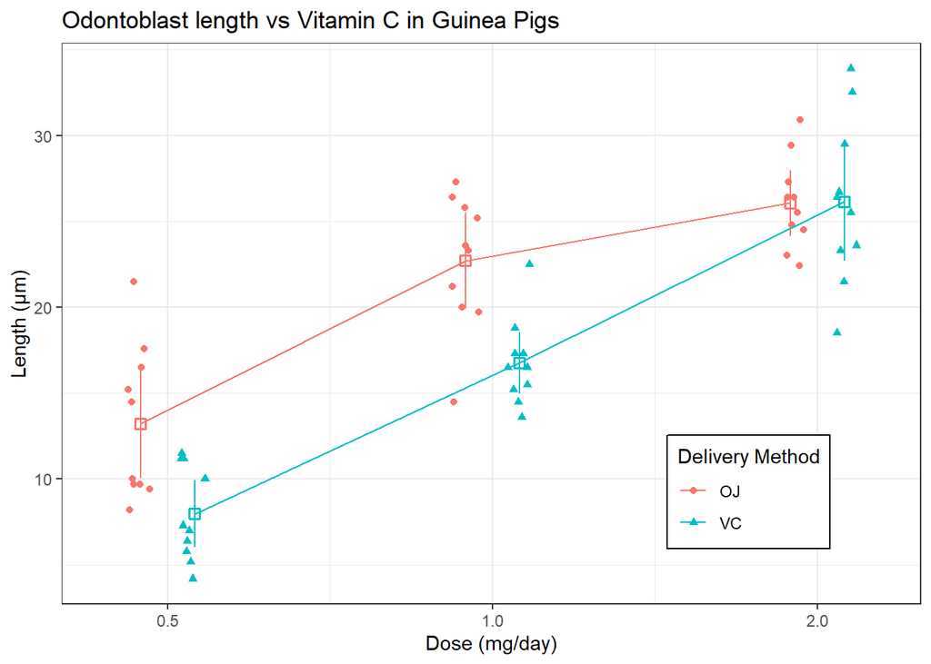

```r
dw <- 0.1
ggplot(s,
       aes(x = dose, color = supp, shape = supp)) +

  geom_point(
    data = ToothGrowth,
    aes(y = len),
    position = position_jitterdodge(dodge.width = dw, jitter.width = 0.05)) +

  geom_pointrange(
    data = s,
    aes(y = mean, ymin = lcl, ymax = ucl),
    position = position_dodge(width = dw),
    shape = 0,
    show.legend = FALSE
    ) +

  geom_line(
    aes(y = mean, group = supp),
    position = position_dodge(width = dw)) +

  scale_x_log10() +

  labs(
    x = "Dose (mg/day)",
    y = "Length (\u00b5m)", # unicode \u00b5 is the Greek letter mu
    title = "Odontoblast length vs Vitamin C in Guinea Pigs",
    color = "Delivery Method",
    shape = "Delivery Method") +

  theme_bw() +
  theme(legend.position = c(0.8, 0.2),
        legend.background = element_rect(fill = "white",
                                        color = "black"))
```

## Advanced tables

The `s` data.frame is not quite ideal for creating a table. We will preview an approach called `pivoting` from the `tidyr` package.

```r
t <- s %>%
  mutate(ci = paste0(format(mean, digits = 1, nsmall = 1),
                    " (",
                    format(lcl,  digits = 1, nsmall = 1),
                    ", ",
                    format(ucl,  digits = 1, nsmall = 1),
                    ")")) %>%
  tidyr::pivot_wider(id_cols = dose, names_from = supp, values_from = ci) %>%
  rename(
    `Orange Juice` = "OJ",
    `Ascorbic Acid` = "VC",
    Dose = dose
  )

t
```

```
## # A tibble: 3 × 3
##    Dose `Orange Juice`    `Ascorbic Acid`
##   <dbl> <chr>             <chr>
## 1   0.5 13.2 (10.0, 16.4) " 8.0 ( 6.0,  9.9)"
## 2   1   22.7 (19.9, 25.5) "16.8 (15.0, 18.6)"
## 3   2   26.1 (24.2, 28.0) "26.1 (22.7, 29.6)"
```

The output above is just the data.frame in R. We can construct better looking tables using a variety of methods.

```r
library("xtable")
cap <- "Mean odonotoblast length (\u00b5m) with 95% CIs."
xt <- xtable::xtable(t,
             caption=cap,
             align="rr|rr")
```

```r
print(xt, type = "html",
      include.rownames = FALSE,
      caption.placement = "top")
```

Mean odonotoblast length (µm) with 95% CIs.

| Dose | Orange Juice | Ascorbic Acid |
| --- | --- | --- |
| 0.50 | 13.2 (10.0, 16.4) | 8.0 ( 6.0, 9.9) |
| 1.00 | 22.7 (19.9, 25.5) | 16.8 (15.0, 18.6) |
| 2.00 | 26.1 (24.2, 28.0) | 26.1 (22.7, 29.6) |

Using knitr::kable

```r
library("knitr")
knitr::kable(t, caption = cap, align = "r")
```

Mean odonotoblast length (µm) with 95% CIs.

| Dose | Orange Juice | Ascorbic Acid |
| --- | --- | --- |
| 0.5 | 13.2 (10.0, 16.4) | 8.0 ( 6.0, 9.9) |
| 1.0 | 22.7 (19.9, 25.5) | 16.8 (15.0, 18.6) |
| 2.0 | 26.1 (24.2, 28.0) | 26.1 (22.7, 29.6) |